# Logistic Regression – The Challenger Disaster

Bayesian / Frequentist Comparison

David Noonan

2018-10-29

The challenger disaster dataset is a classic tool for teaching demonstrating logistic regression. Here I’m going to compare results from frequentist and bayesian logistic regressions model. Firstly, we need to load the dataset. I found it conveniently in the DAAG package, so let’s load it up:

```r
library(DAAG) # DAAG library contains the challenger dataset
library(tidyverse)
library(rstan)
library(bayesplot)
options(mc.cores = parallel::detectCores())
rstan_options(auto_write = TRUE)

Sys.setenv(USE_CXX14 = 1)

# load the challenger "o-rings" dataset
chall <- orings
str(chall)
```

```
## 'data.frame':    23 obs. of  4 variables:
##  $ Temperature: num  53 57 58 63 66 67 67 67 68 69 ...
##  $ Erosion    : num  3 1 1 1 0 0 0 0 0 0 ...
##  $ Blowby     : num  2 0 0 0 0 0 0 0 0 0 ...
##  $ Total      : num  5 1 1 1 0 0 0 0 0 0 ...
```

We have essentially four variables here: “Temperature” – the air temperature at “launch” (experimental launch simulation, I believe), “Blowby” – when the o-ring leaks fuel, and “Erosion” – where the o-ring erodes, and “Total” – a combination of “Erosion” and “Blowby”. We are interested in temperature, which we’ll use to explain the outcome, and we are also “Total”, which combines both types of o-ring failures that cause the shuttle to fail or explode. Below is a chart of “Total” by temperature:

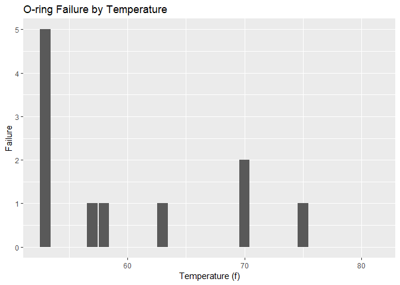

```r
# plot failures by temperature

ggplot() +
  geom_col(
    data = chall,
    mapping = aes(
      x = Temperature,
      y = Total
    )
  ) +
  ggtitle(label = "O-ring Failure by Temperature") +
  xlab("Temperature (f)") +
  ylab("Failure")
```

We can already see what looks like a trend: Lower temperatures cause more failures. For now, we’ll pay attention to the presence of failure, rather than the number of o-ring failures, or the type. Here we create a new variable, “Failure”, which indicates the presence or absence of failure:

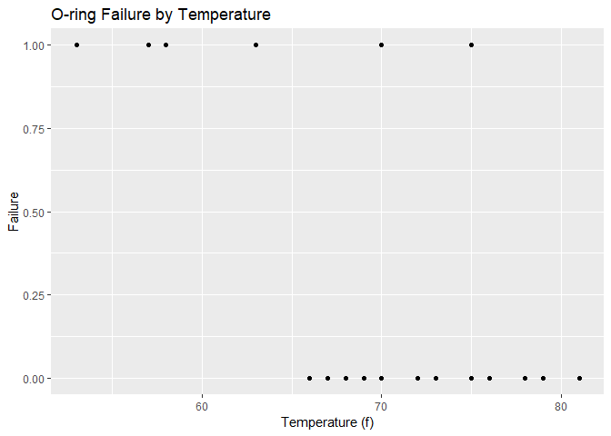

```r
# Create failure variable, 1 = failure, 0 = no failure
challenger <- orings %>% mutate(Failure = ifelse(test = Total > 0,
  yes = 1,
  no = 0
))

# plot failure by temperature
ggplot() +
  geom_point(
    data = challenger,
    mapping = aes(
      x = Temperature,
      y = Failure
    )
  ) +
  ggtitle(label = "O-ring Failure by Temperature") +
  xlab("Temperature (f)") +
  ylab("Failure")
```

Now we’ll do what the textbooks do: build a logistic regression model, and predict the outcomes for low-temperature launches! We begin by testing our model setup by generating fake data with known parameters. We’ll test the setup by estimating the parameters with our model. If it estimates the parameters correctly, it tells us that our model “works” as far as coding is concerned.

Below we simulate data from the model
$$Failure \thicksim Bernoulli(\pi)$$
Where $\pi$ depends on temperature with the relationship
$$\pi = \frac{1}{(1 + \exp(-(\alpha + \beta*Temperature))}$$
I’ll choose $\alpha = 20$ and $\beta = -0.4$.

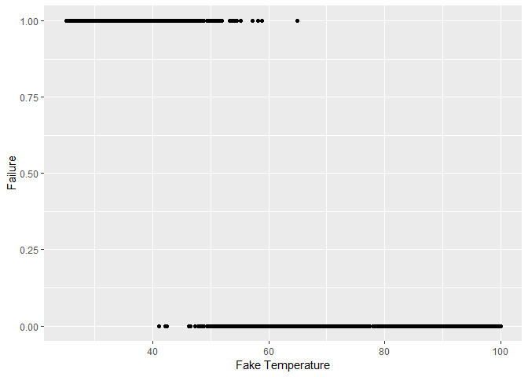

```r
# Create some fake data - logistic regression
set.seed(88)
N <- 1000
alpha <- 20
beta <- -.4

fake_temperature <- runif(N, min = 25, max = 100) # generate random temperatures between 25 and 100
pi <- 1 / (1 + exp(-(alpha + beta * fake_temperature))) # generate failure probabilities from the temperatures
failure <- rbinom(N, 1, pi) # simulate Bernoulli trials from the generated temperatures

fake_data <- data.frame(fake_temperature = fake_temperature, pi = pi, failure = failure)

ggplot(data = fake_data, aes(x = fake_temperature, y = failure)) +
  geom_point() +
  labs(x = "Fake Temperature", y = "Failure")
```

Looks reasonable. Here, the risk of failure increases sharply as temperatures decrease below 60, as shown below:

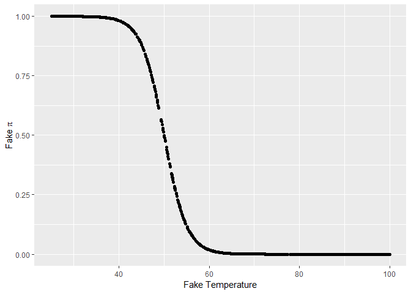

```r
ggplot(data = fake_data, aes(x = fake_temperature, y = pi)) +
  geom_point() +
  labs(x = "Fake Temperature", y = expression(Fake~pi))
```

Now let’s fit a model in stan. I’ll use very weak priors, because I have essentially zero prior knowledge about the effect of temperature on o-ring failure. Next, the model we are specifying is:
$$Failure \thicksim Bernoulli(\pi) \\
\pi = \frac{1}{(1 + \exp(-(\alpha + \beta*Temperature))} \\
\alpha \thicksim \mathcal{N}(\mu_{\alpha}, \sigma_{\alpha}) \\
\beta \thicksim \mathcal{N}(\mu_{\beta}, \sigma_{\beta})$$

```r
stan_model_string <- "data {
  int<lower = 1> N;
  vector[N] fake_temperature;
  int<lower = 0, upper = 1> failure[N];
}
parameters {
  real alpha;
  real beta;
}
model {
  failure ~ bernoulli_logit(alpha + beta*fake_temperature);
  alpha ~ normal(0, 100);
  beta ~ normal(0, 10);
}
generated quantities {
  //vector[N_test] y_test;
  //for(i in 1:N_test) {
   // failure_test[i] = bernoulli_rng(inv_logit(alpha + beta*temperature_test[i]));
  }
}"
```

Then we format the data into a list:

```r
fake_stan_data <- list(failure = fake_data$failure, fake_temperature = fake_data$fake_temperature, N = nrow(fake_data))
```

```r
# Recover parameters with stan
fit1 <- stan(file = 'challenger.stan',
            data = fake_stan_data,
            chains = 3, iter = 1000,)
```

Did the mcmc sampling work? Let’s check the trace plot:

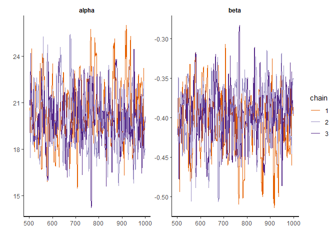

```r
traceplot(fit1)
```

Looks like it converges. Now the estimates:

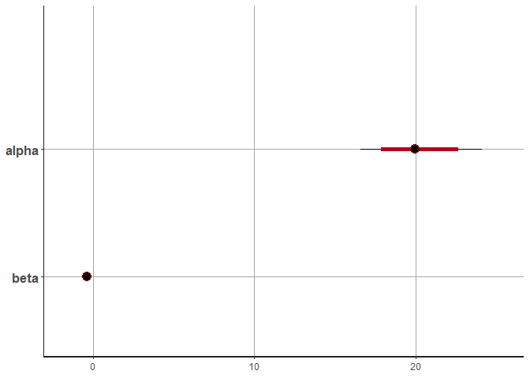

```r
plot(fit1, pars = c("alpha", "beta"))
```

```r
print(fit1)
```

```
## Inference for Stan model: challenger.
## 3 chains, each with iter=1000; warmup=500; thin=1;
## post-warmup draws per chain=500, total post-warmup draws=1500.
##
##          mean se_mean   sd    2.5%     25%     50%     75%   97.5% n_eff
## alpha   20.15    0.12 1.90   16.59   18.84   19.98   21.42   24.13   259
## beta    -0.40    0.00 0.04   -0.48   -0.43   -0.40   -0.37   -0.33   260
## lp__  -102.83    0.05 1.07 -105.69 -103.21 -102.52 -102.09 -101.80   460
##       Rhat
## alpha 1.03
## beta  1.03
## lp__  1.00
##
## Samples were drawn using NUTS(diag_e) at Mon Oct 29 21:05:59 2018.
## For each parameter, n_eff is a crude measure of effective sample size,
## and Rhat is the potential scale reduction factor on split chains (at
## convergence, Rhat=1).
```

The means for our alpha and beta parameters are reasonable! Let’s do a quick plot look at what our model says about pi relating to temperature. We’ll put in fake temperature data, and see what distributions for pi come out of it.

```r
#From https://stats.stackexchange.com/questions/252988/highest-density-interval-in-stan

HDIofMCMC = function( sampleVec , credMass=0.95 ) {
  # Computes highest density interval from a sample of representative values,
  #   estimated as shortest credible interval.
  # Arguments:
  #   sampleVec
  #     is a vector of representative values from a probability distribution.
  #   credMass
  #     is a scalar between 0 and 1, indicating the mass within the credible
  #     interval that is to be estimated.
  # Value:
  #   HDIlim is a vector containing the limits of the HDI
  sortedPts = sort( sampleVec )
  ciIdxInc = ceiling( credMass * length( sortedPts ) )
  nCIs = length( sortedPts ) - ciIdxInc
  ciWidth = rep( 0 , nCIs )
  for ( i in 1:nCIs ) {
    ciWidth[ i ] = sortedPts[ i + ciIdxInc ] - sortedPts[ i ]
  }
  HDImin = sortedPts[ which.min( ciWidth ) ]
  HDImax = sortedPts[ which.min( ciWidth ) + ciIdxInc ]
  HDIlim = c( HDImin , HDImax )
  return( HDIlim )
}
```

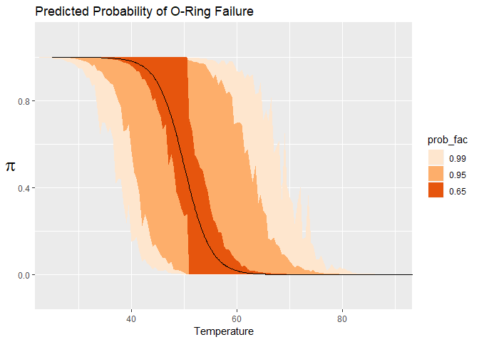

```r
#gather samples from the fit1 model
fit1_samples <- rstan::extract(fit1)

#extract alpha and beta posterior samples
fit1_alpha_posterior <- fit1_samples$alpha
fit1_beta_posterior <- fit1_samples$beta

#generate fake temperature data
fake_temps <- seq(20, 120, by = .5) #runif(n = 1000, min = 0, max = 130)

#function to generate samples of pi
gen_pi <- function(temperature) {
  logit_pi_sample <- sample(x = fit1_alpha_posterior, size = 1, replace = TRUE) + sample(x = fit1_beta_posterior, size = 1, replace = TRUE)*temperature
  pi_sample <- 1/(1 + exp(-logit_pi_sample))
  return(pi_sample)
}

#function to reapeat pi generation 1000 times
gen_pi_1000 <- function(temperature) {
  as.list(rep(temperature, 1000)) %>% map_dbl(gen_pi) %>% unlist()
}

#create list of 1000 samples for each temperature
combined_pi <- as.list(fake_temps) %>%
  map(gen_pi_1000)


#function to take the list of pi samples, generate 95% and 50% HDIs, and store them in a data frame.
calculate_50_95_hdi <- function(list_element, temperature) {
hdi_test_65 <- list_element %>% HDIofMCMC(credMass = .65)
hdi_test_95 <- list_element %>% HDIofMCMC(credMass = .95)
hdi_test_99 <- list_element %>% HDIofMCMC(credMass = .99)

HDI_data_frame <- data.frame(temp = rep(temperature, 3, ), prob = c(.65, .95, .99), lower = c(hdi_test_65[1], hdi_test_95[1], hdi_test_99[1]), upper = c(hdi_test_65[2], hdi_test_95[2], hdi_test_99[2]))

return(HDI_data_frame)
}


#apply hdi function to pi samples, combine to a dataframe
pi_hdi <- purrr::map2(combined_pi, as.list(fake_temps), calculate_50_95_hdi) %>% rbind_list()
pi_hdi %>%
  ungroup %>%
  mutate(prob_fac = factor(prob),
         prob_fac = forcats::fct_reorder(prob_fac, prob, .desc = TRUE)) %>%
  ggplot(aes(x = temp, y = upper)) +
  geom_ribbon(aes(ymin = lower, ymax = upper, fill = prob_fac)) +
  scale_fill_brewer(palette = "Oranges", direction = 1) +
  coord_cartesian(ylim = c(-.1, 1.1), xlim = c(25, 90)) +
 geom_line(aes(x = fake_temperature, y = pi), data = fake_data) +
  labs(title = "Predicted Probability of O-Ring Failure",
       x = "Temperature",
       y = expression(pi)) +
  theme(axis.title.y = element_text(size = 20, angle = 0, vjust = .5))
```